# NEURAL NETWORKS - COMPUTER VISION

## Ricardo López Ruiz

Date: 26/07/2021

## Abstract:

Convolutional Neural Networks (CNN) are trained to classify plant's species from the images taken of the plants.

## Tools used in this project:

'Tensorflow', 'Keras', 'CNN', 'Input/Hidden/Output Layers'

# Project - Image Classification using CNNs in Keras

## Goal:

The goal of the project is to create a classifier capable of determining a plant's species from a photo.

## Data Description:

You are provided with a dataset of images of plant seedlings at various stages of grown. Each image has a filename that is its unique id. The dataset comprises 12 plant species.

## Dataset:

The data file names are:

- images.npy
- Label.csv

The original files are from Kaggle. Due to the large volume of data, the images were converted to images.npy file and the labels are also put into the Labels.csv.

## Steps and Tasks

- Import the libraries, load dataset, print shape of data, visualize the images in dataset.
- Data Pre-processing:
  - Normalization.
  - Gaussian Blurring.
  - Visualize data after pre-processing.
- Make data compatible:
  - Convert labels to one-hot-vectors.
  - Print the label for some element i of y_train[].
  - Split the dataset into training, testing, and validation set.
  - Check the shape of data, reshape data into shapes compatible with Keras models if it’s not already.
- Building CNN:
  - Define layers.
  - Set optimizer and loss function. (Use Adam optimizer and categorical crossentropy.)
- Fit and evaluate model and print confusion matrix.
- Visualize predictions for some elements i of x_test[].

## Libraries and Datasets

**Import the libraries**

```python
# Importing the libraries to be used
import numpy as np
import pandas as pd
import collections

import cv2
import seaborn as sns
import matplotlib.pyplot as plt
%matplotlib inline

# Suppress warnings
import warnings
warnings.filterwarnings('ignore')
```

```python
# Importing tensorflow
import tensorflow
tensorflow.__version__
from tensorflow.keras.utils import to_categorical
```

**Loading the data**

```python
# Loading the file of the plant images as a numpy array
images = np.load('images.npy')
type(images)
```

```
numpy.ndarray
```

```python
# Loading the labels of the plants as a dataframe
labels = pd.read_csv('Labels.csv')
type(labels)
```

```
pandas.core.frame.DataFrame
```

**Shape of data**

```python
# Info of the images array
print('The shape of images dataset is: ', images.shape)
# Number of images stored in the array
print('The number of the images is: ', images.shape[0])
# Extracting the height and width of an image
h, w = images.shape[1:3]
# Displaying the height and width of an image
print("Size of the images is: Height = {},  Width = {}".format(h, w))
# Number of images stored in the array
print('The number of image colors is: ', images.shape[3])
```

```
The shape of images dataset is:  (4750, 128, 128, 3)
The number of the images is:  4750
Size of the images is: Height = 128,  Width = 128
The number of image colors is:  3
```

```python
# Shape of the labels
print(labels.size)
print(labels.shape)
print(labels.info())
labels
```

```
4750
(4750, 1)
<class 'pandas.core.frame.DataFrame'>
RangeIndex: 4750 entries, 0 to 4749
Data columns (total 1 columns):
 #   Column  Non-Null Count  Dtype
---  ------  --------------  -----
 0   Label   4750 non-null   object
dtypes: object(1)
memory usage: 37.2+ KB
None
```

|  | Label |
| --- | --- |
| 0 | Small-flowered Cranesbill |
| 1 | Small-flowered Cranesbill |
| 2 | Small-flowered Cranesbill |
| 3 | Small-flowered Cranesbill |
| 4 | Small-flowered Cranesbill |
| ... | ... |
| 4745 | Loose Silky-bent |
| 4746 | Loose Silky-bent |
| 4747 | Loose Silky-bent |
| 4748 | Loose Silky-bent |
| 4749 | Loose Silky-bent |

4750 rows × 1 columns

**Visualize some images of the dataset**

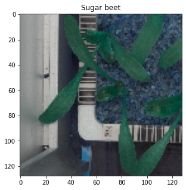

```python
# Plotting one of the images
i=3500
plt.figure(figsize = (5,5))
plt.imshow(images[i])
plt.title(str(labels.iloc[i,0]))
```

```python
#image i with 128x128 pixels
i=3500
print('Size of one image --> 128x128x3: ', 128*128*3,' = ',images[i].size)
print('Array of this image: ','\n',images[i])
```

```
Size of one image --> 128x128x3:  49152  =  49152
Array of this image:
 [[[142 144 142]
  [147 147 147]
  [142 145 145]
  ...
  [ 29  43  62]
  [ 62  85 116]
  [ 45  76 109]]

 [[140 142 143]
  [144 146 145]
  [146 149 149]
  ...
  [ 44  65  90]
  [ 64  93 115]
  [ 54  81 107]]

 [[141 141 144]
  [143 144 144]
  [145 146 146]
  ...
  [ 51  68 102]
  [ 74  92 104]
  [ 28  35  52]]

 ...

 [[ 83  89  92]
  [ 81  89  91]
  [ 80  84  90]
  ...
  [ 45  45  50]
  [ 39  37  41]
  [ 64  61  67]]

 [[ 79  87  91]
  [ 80  89  90]
  [ 74  78  80]
  ...
  [ 44  43  47]
  [ 41  40  44]
  [ 37  36  40]]

 [[ 78  86  88]
  [ 78  82  84]
  [ 73  79  79]
  ...
  [ 50  47  49]
  [ 49  45  53]
  [ 44  41  46]]]
```

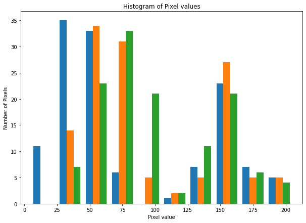

```python
# Plotting RGB pixel values for one row of the images[i]
plt.figure(figsize=(10,7))
i, row = 3500 , 55
counts, bins, bars = plt.hist(images[i][row])
plt.xlabel('Pixel value')
plt.ylabel('Number of Pixels')
plt.title('Histogram of Pixel values')
plt.show()
```

```python
# Counting values assigned to pixel (a,b) of image i
i,a,b = 3500,10,20
print('Length of the array: ',len(images[i][a][b]))
print(collections.Counter(images[i][a][b]))
print(np.bincount(images[i][a][b]))
```

```
Length of the array:  3
Counter({201: 1, 199: 1, 195: 1})
[0 0 0 0 0 0 0 0 0 0 0 0 0 0 0 0 0 0 0 0 0 0 0 0 0 0 0 0 0 0 0 0 0 0 0 0 0
 0 0 0 0 0 0 0 0 0 0 0 0 0 0 0 0 0 0 0 0 0 0 0 0 0 0 0 0 0 0 0 0 0 0 0 0 0
 0 0 0 0 0 0 0 0 0 0 0 0 0 0 0 0 0 0 0 0 0 0 0 0 0 0 0 0 0 0 0 0 0 0 0 0 0
 0 0 0 0 0 0 0 0 0 0 0 0 0 0 0 0 0 0 0 0 0 0 0 0 0 0 0 0 0 0 0 0 0 0 0 0 0
 0 0 0 0 0 0 0 0 0 0 0 0 0 0 0 0 0 0 0 0 0 0 0 0 0 0 0 0 0 0 0 0 0 0 0 0 0
 0 0 0 0 0 0 0 0 0 0 1 0 0 0 1 0 1]
```

```python
#image 1, pixel 1x1 --> first pixel of the file
print(images[0][0][0])
#image 4750, pixel 128x128 --> last pixel of the file
print(images[4749][127][127])
```

```
[35 52 78]
[ 68  84 101]
```

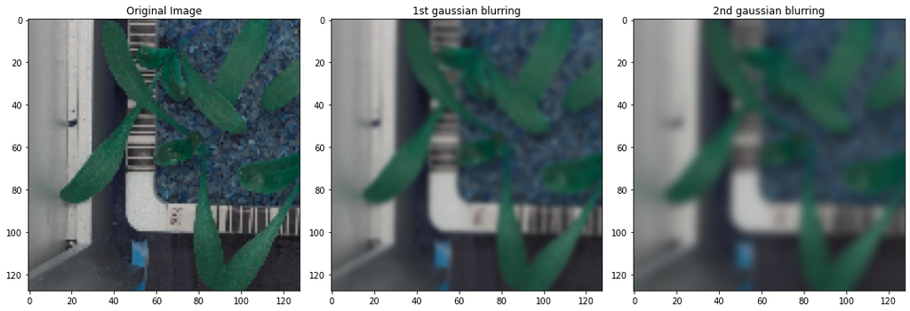

```python
#Example of Gaussian blurring to reduce the image noise
i=3500
Gaussian1 = cv2.GaussianBlur(images[i], (5, 5), 0)
Gaussian2 = cv2.GaussianBlur(images[i], (11,11), 0)
#Plotting the 3 images together with subplot
axes=[]
fig=plt.figure(figsize = (15,15))
#Original image
axes.append(fig.add_subplot(1, 3, 1))
subplot_title=('Original Image')
axes[-1].set_title(subplot_title)
plt.imshow(images[i])
#Blurred 1st image
axes.append(fig.add_subplot(1, 3, 2))
subplot_title=('1st gaussian blurring')
axes[-1].set_title(subplot_title)
plt.imshow(Gaussian1)
#Blurred 2nd image
axes.append(fig.add_subplot(1, 3, 3))
subplot_title=('2nd gaussian blurring')
axes[-1].set_title(subplot_title)
plt.imshow(Gaussian2)
#Plotting total image
fig.tight_layout()
plt.show()
```

```python
# Non null values in labels
print(labels.count())
print(labels.isna().sum())
print(labels.isnull().sum(axis=0))
```

```
Label    4750
dtype: int64
Label    0
dtype: int64
Label    0
dtype: int64
```

```python
# Counting the different Labels in the dataset
print('Set of Labels: ', len(set(labels['Label'])),'\n', labels['Label'].unique(),'\n')
print('Number of each Label: ', '\n', labels.value_counts(),'\n')
print('Total data: ', labels.value_counts().sum())
```

```
Set of Labels:  12
 ['Small-flowered Cranesbill' 'Fat Hen' 'Shepherds Purse' 'Common wheat'
 'Common Chickweed' 'Charlock' 'Cleavers' 'Scentless Mayweed' 'Sugar beet'
 'Maize' 'Black-grass' 'Loose Silky-bent']

Number of each Label:
 Label
Loose Silky-bent             654
Common Chickweed             611
Scentless Mayweed            516
Small-flowered Cranesbill    496
Fat Hen                      475
Charlock                     390
Sugar beet                   385
Cleavers                     287
Black-grass                  263
Shepherds Purse              231
Common wheat                 221
Maize                        221
dtype: int64

Total data:  4750
```

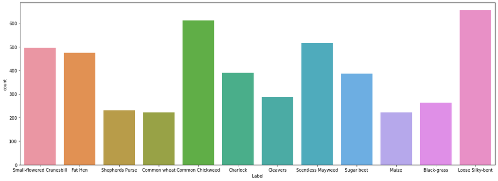

```python
# Visualizing the number of each plant class
plt.figure(figsize=(20,7))
sns.countplot(labels['Label'])
```

## Data Preprocessing

**Normalization of dataset**

```python
# Normalize the data
images1 = images.astype('float32') / 255.0
```

```python
#image 1, pixel 1x1 --> first pixel of the file
print(images1[0][0][0])
#image 4750, pixel 128x128 --> last pixel of the file
print(images1[4749][127][127])
```

```
[0.13725491 0.20392157 0.30588236]
[0.26666668 0.32941177 0.39607844]
```

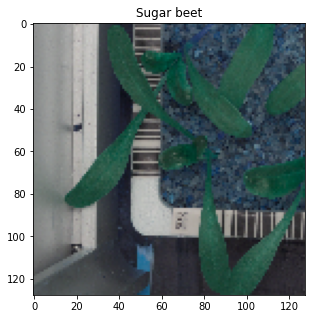

```python
# Plot of one of the images already normalized
i=3500
plt.figure(figsize = (5,5))
plt.imshow(images1[i])
plt.title(str(labels.iloc[i,0]))
```

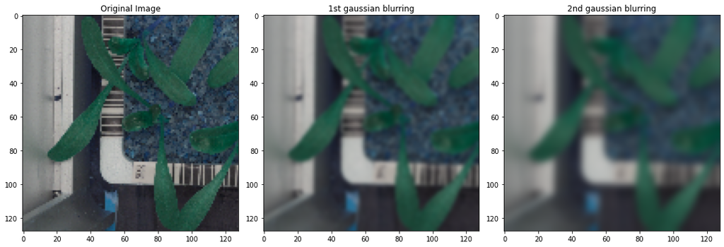

```python
#Example of Gaussian blurring to reduce the image noise in normalized images
i=3500
Gaussian1 = cv2.GaussianBlur(images1[i], (5, 5), 0)
Gaussian2 = cv2.GaussianBlur(images1[i], (11,11), 0)
#Plotting the 3 images together with subplot
axes=[]
fig=plt.figure(figsize = (15,15))
#Original image
axes.append(fig.add_subplot(1, 3, 1))
subplot_title=('Original Image')
axes[-1].set_title(subplot_title)
plt.imshow(images[i])
#Blurred 1st image
axes.append(fig.add_subplot(1, 3, 2))
subplot_title=('1st gaussian blurring')
axes[-1].set_title(subplot_title)
plt.imshow(Gaussian1)
#Blurred 2nd image
axes.append(fig.add_subplot(1, 3, 3))
subplot_title=('2nd gaussian blurring')
axes[-1].set_title(subplot_title)
plt.imshow(Gaussian2)
#Plotting total image
fig.tight_layout()
plt.show()
```

**Gaussian Blurring**

```python
#Gaussian blurring of the whole images set
Gaussian_X = []
print(type(Gaussian_X))

for i in range(0,images.shape[0]):
    Gaussian_x = cv2.GaussianBlur(images1[i], (5, 5), 0)
    Gaussian_X.append(Gaussian_x)

Gaussian_X = np.array(Gaussian_X)
print(type(Gaussian_X))
```

```
<class 'list'>
<class 'numpy.ndarray'>
```

```python
# Info of the new blurred images array
print('The shape of images dataset is: ', Gaussian_X.shape)
# Number of images stored in the array
print('The number of the images is: ', Gaussian_X.shape[0])
# Extracting the height and width of an image
h, w = Gaussian_X.shape[1:3]
# Displaying the height and width of an image
print("Size of the images is: Height = {},  Width = {}".format(h, w))
# Number of images stored in the array
print('The number of image colors is: ', Gaussian_X.shape[3])
```

```
The shape of images dataset is:  (4750, 128, 128, 3)
The number of the images is:  4750
Size of the images is: Height = 128,  Width = 128
The number of image colors is:  3
```

**Visualizing data after preprocessing**

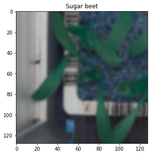

```python
# Plot of one of the images of the new blurred images set
i=3500
plt.figure(figsize = (5,5))
plt.imshow(Gaussian_X[i])
plt.title(str(labels.iloc[i,0]))
```

## Make Data Compatible

**Convert labels to one-hot vectors**

```python
#Converting name of plants in integer numbers
r = labels['Label'].astype("category")
labels['n_plant'] = r.cat.codes
print(labels)
print(labels.info())
```

```
                          Label  n_plant
0     Small-flowered Cranesbill       10
1     Small-flowered Cranesbill       10
2     Small-flowered Cranesbill       10
3     Small-flowered Cranesbill       10
4     Small-flowered Cranesbill       10
...                         ...      ...
4745           Loose Silky-bent        6
4746           Loose Silky-bent        6
4747           Loose Silky-bent        6
4748           Loose Silky-bent        6
4749           Loose Silky-bent        6

[4750 rows x 2 columns]
<class 'pandas.core.frame.DataFrame'>
RangeIndex: 4750 entries, 0 to 4749
Data columns (total 2 columns):
 #   Column   Non-Null Count  Dtype
---  ------   --------------  -----
 0   Label    4750 non-null   object
 1   n_plant  4750 non-null   int8
dtypes: int8(1), object(1)
memory usage: 41.9+ KB
None
```

```python
#Relation between the Label and the n_plant
labels1 = labels.groupby("Label", as_index=True).median()
labels1
```

| Label | n_plant |
| --- | --- |
| Black-grass | 0 |
| Charlock | 1 |
| Cleavers | 2 |
| Common Chickweed | 3 |
| Common wheat | 4 |
| Fat Hen | 5 |
| Loose Silky-bent | 6 |
| Maize | 7 |
| Scentless Mayweed | 8 |
| Shepherds Purse | 9 |
| Small-flowered Cranesbill | 10 |
| Sugar beet | 11 |

```python
#Conversion of the n_plant to numpy array
print('DataType of Labels: ',type(labels))
n_plants=labels['n_plant'].values
print('DataType of n_plants: ',type(n_plants))
print('Array n_plants = ',n_plants)
print('Number of elementis: ',len(n_plants))
```

```
DataType of Labels:  <class 'pandas.core.frame.DataFrame'>
DataType of n_plants:  <class 'numpy.ndarray'>
Array n_plants =  [10 10 10 ...  6  6  6]
Number of elementis:  4750
```

**Printing the label for y_plants[0]**

```python
# Conversion to one-hot vectors of the n_plants
y_plants = to_categorical(n_plants, num_classes=12)

print("Shape of y_plants:", y_plants.shape)
print("One value of y_plants:", y_plants[0])
print("This represents n_plant:", n_plants[0], ", which is:", labels.iloc[0,0] )
```

```
Shape of y_plants: (4750, 12)
One value of y_plants: [0. 0. 0. 0. 0. 0. 0. 0. 0. 0. 1. 0.]
This represents n_plant: 10 , which is: Small-flowered Cranesbill
```

**Splitting the dataset**

```python
# Preparing and checking right format of data to build the CNN
X = Gaussian_X.copy()
y = y_plants.copy()
print(type(X))
print(type(y))
```

```
<class 'numpy.ndarray'>
<class 'numpy.ndarray'>
```

```python
# Splitting data into test and train to build the model.
from sklearn.model_selection import train_test_split
X_train, X_test, y_train, y_test = train_test_split(X, y, train_size=0.70, random_state=0)
```

```python
# We can see that the data to be fed into model is of the type numpy array
print(type(X_train))
print(type((y_train)))
```

```
<class 'numpy.ndarray'>
<class 'numpy.ndarray'>
```

**Data in correct shape**

```python
# Dataset X shape
print("X_train shape:", X_train.shape)
print("Images in X_train:", X_train.shape[0])
print("Images in X_test:", X_test.shape[0])
print("Max value in X_train:", X_train.max())
print("Min value in X_train:", X_train.min())
```

```
X_train shape: (3325, 128, 128, 3)
Images in X_train: 3325
Images in X_test: 1425
Max value in X_train: 0.99903494
Min value in X_train: 0.0
```

```python
# Dataset y shape
print("Shape of y_train:", y_train.shape)
print("One value of y_train:", y_train[0])
```

```
Shape of y_train: (3325, 12)
One value of y_train: [1. 0. 0. 0. 0. 0. 0. 0. 0. 0. 0. 0.]
```

## Building CNN

**Importing required libraries**

```python
from tensorflow.keras.models import Sequential          # Sequential groups a linear stack of layers into a tf.keras.Model.
from tensorflow.keras.layers import Conv2D              # This layer creates a convolution kernel that is convolved with the layer input to produce a tensor of outputs.
from tensorflow.keras.layers import MaxPooling2D        # Max pooling operation for 2D spatial data.
from tensorflow.keras.layers import Flatten             # Flattens the input. Does not affect the batch size.
from tensorflow.keras.layers import Dense, Dropout      # Dropout: Applies Dropout to the input.
                                                        # Dense: Just your regular densely-connected NN layer.
```

**Defining layers**

```python
# Initialising the CNN classifier
classifier = Sequential()

# Add a Convolution layer with 32 kernels of 3X3 shape with activation function ReLU
classifier.add(Conv2D(32, (5, 5), input_shape = (128, 128, 3), activation = 'relu', padding = 'same'))

# Add a Max Pooling layer of size 2X2
classifier.add(MaxPooling2D(pool_size = (2, 2)))

# Adding dropout with probability 0.2
classifier.add(Dropout(0.2))

# Add another Convolution layer with 64 kernels of 3X3 shape with activation function ReLU
classifier.add(Conv2D(64, (3, 3), activation = 'relu', padding = 'same'))

# Adding another pooling layer
classifier.add(MaxPooling2D(pool_size = (2, 2)))

# Adding dropout with probability 0.3
classifier.add(Dropout(0.3))

# Add another Convolution layer with 32 kernels of 3X3 shape with activation function ReLU
classifier.add(Conv2D(64, (3, 3), activation = 'relu', padding = 'valid'))

# Adding another pooling layer
classifier.add(MaxPooling2D(pool_size = (2, 2)))

# Adding dropout with probability 0.4
classifier.add(Dropout(0.4))

# Flattening the layer before fully connected layers
classifier.add(Flatten())

# Adding a fully connected layer with 512 neurons
classifier.add(Dense(units = 512, activation = 'relu'))

# Adding dropout with probability 0.5
classifier.add(Dropout(0.5))

# Adding a fully connected layer with 128 neurons
classifier.add(Dense(units = 128, activation = 'relu'))

# Adding dropout with probability 0.5
classifier.add(Dropout(0.5))

# The final output layer with 12 neurons to predict the categorical classifcation
classifier.add(Dense(units = 12, activation = 'softmax'))

# Summary of the model
classifier.summary()
```

```
Model: "sequential"
_________________________________________________________________
Layer (type)                 Output Shape              Param #
=================================================================
conv2d (Conv2D)              (None, 128, 128, 32)      2432
_________________________________________________________________
max_pooling2d (MaxPooling2D) (None, 64, 64, 32)        0
_________________________________________________________________
dropout (Dropout)            (None, 64, 64, 32)        0
_________________________________________________________________
conv2d_1 (Conv2D)            (None, 64, 64, 64)        18496
_________________________________________________________________
max_pooling2d_1 (MaxPooling2 (None, 32, 32, 64)        0
_________________________________________________________________
dropout_1 (Dropout)          (None, 32, 32, 64)        0
_________________________________________________________________
conv2d_2 (Conv2D)            (None, 30, 30, 64)        36928
_________________________________________________________________
max_pooling2d_2 (MaxPooling2 (None, 15, 15, 64)        0
_________________________________________________________________
dropout_2 (Dropout)          (None, 15, 15, 64)        0
_________________________________________________________________
flatten (Flatten)            (None, 14400)             0
_________________________________________________________________
dense (Dense)                (None, 512)               7373312
_________________________________________________________________
dropout_3 (Dropout)          (None, 512)               0
_________________________________________________________________
dense_1 (Dense)              (None, 128)               65664
_________________________________________________________________
dropout_4 (Dropout)          (None, 128)               0
_________________________________________________________________
dense_2 (Dense)              (None, 12)                1548
=================================================================
Total params: 7,498,380
Trainable params: 7,498,380
Non-trainable params: 0
_________________________________________________________________
```

**Setting optimizer and loss function**

```python
#Adding Early stopping callback to the fit function is going to stop the training,
#if the val_loss is not going to change even '0.005' for more than 10 continous epochs
from tensorflow.keras.callbacks import ModelCheckpoint, EarlyStopping
from tensorflow.keras import optimizers

# initiate Adam optimizer
opt = optimizers.Adam(learning_rate=0.001, beta_1=0.9, beta_2=0.999, epsilon=1e-08)

# Compile the model
classifier.compile(loss="categorical_crossentropy", metrics=["accuracy"], optimizer=opt)

# Use earlystopping
early_stopping = EarlyStopping(monitor='val_loss', patience=10, min_delta=0.005)

#Adding Model Checkpoint callback to the fit function is going to save the weights whenever val_loss achieves a new low value.
#Hence saving the best weights occurred during training
model_checkpoint =  ModelCheckpoint('cifar_cnn_checkpoint_{epoch:02d}_loss{val_loss:.4f}.h5',
                                                           monitor='val_loss',
                                                           verbose=1,
                                                           save_best_only=True,
                                                           save_weights_only=True,
                                                           mode='auto',
                                                           period=1)
# Summary of the model
classifier.summary()
```

```
WARNING:tensorflow:`period` argument is deprecated. Please use `save_freq` to specify the frequency in number of batches seen.
Model: "sequential"
_________________________________________________________________
Layer (type)                 Output Shape              Param #
=================================================================
conv2d (Conv2D)              (None, 128, 128, 32)      2432
_________________________________________________________________
max_pooling2d (MaxPooling2D) (None, 64, 64, 32)        0
_________________________________________________________________
dropout (Dropout)            (None, 64, 64, 32)        0
_________________________________________________________________
conv2d_1 (Conv2D)            (None, 64, 64, 64)        18496
_________________________________________________________________
max_pooling2d_1 (MaxPooling2 (None, 32, 32, 64)        0
_________________________________________________________________
dropout_1 (Dropout)          (None, 32, 32, 64)        0
_________________________________________________________________
conv2d_2 (Conv2D)            (None, 30, 30, 64)        36928
_________________________________________________________________
max_pooling2d_2 (MaxPooling2 (None, 15, 15, 64)        0
_________________________________________________________________
dropout_2 (Dropout)          (None, 15, 15, 64)        0
_________________________________________________________________
flatten (Flatten)            (None, 14400)             0
_________________________________________________________________
dense (Dense)                (None, 512)               7373312
_________________________________________________________________
dropout_3 (Dropout)          (None, 512)               0
_________________________________________________________________
dense_1 (Dense)              (None, 128)               65664
_________________________________________________________________
dropout_4 (Dropout)          (None, 128)               0
_________________________________________________________________
dense_2 (Dense)              (None, 12)                1548
=================================================================
Total params: 7,498,380
Trainable params: 7,498,380
Non-trainable params: 0
_________________________________________________________________
```

## Fit and Evaluate the Model

```
Epoch 00001: val_loss improved from inf to 2.40737, saving model to cifar_cnn_checkpoint_01_loss2.4074.h5
Epoch 00002: val_loss improved from 2.40737 to 2.07752, saving model to cifar_cnn_checkpoint_02_loss2.0775.h5
Epoch 00003: val_loss improved from 2.07752 to 1.80650, saving model to cifar_cnn_checkpoint_03_loss1.8065.h5
Epoch 00004: val_loss improved from 1.80650 to 1.70615, saving model to cifar_cnn_checkpoint_04_loss1.7061.h5
Epoch 00005: val_loss improved from 1.70615 to 1.61700, saving model to cifar_cnn_checkpoint_05_loss1.6170.h5
Epoch 00006: val_loss improved from 1.61700 to 1.52693, saving model to cifar_cnn_checkpoint_06_loss1.5269.h5
Epoch 00007: val_loss improved from 1.52693 to 1.47452, saving model to cifar_cnn_checkpoint_07_loss1.4745.h5
Epoch 00008: val_loss improved from 1.47452 to 1.41151, saving model to cifar_cnn_checkpoint_08_loss1.4115.h5
Epoch 00009: val_loss improved from 1.41151 to 1.28063, saving model to cifar_cnn_checkpoint_09_loss1.2806.h5
Epoch 00010: val_loss improved from 1.28063 to 1.24519, saving model to cifar_cnn_checkpoint_10_loss1.2452.h5
Epoch 00011: val_loss improved from 1.24519 to 1.16601, saving model to cifar_cnn_checkpoint_11_loss1.1660.h5
Epoch 00012: val_loss improved from 1.16601 to 1.13122, saving model to cifar_cnn_checkpoint_12_loss1.1312.h5
Epoch 00013: val_loss improved from 1.13122 to 1.09328, saving model to cifar_cnn_checkpoint_13_loss1.0933.h5
Epoch 00014: val_loss improved from 1.09328 to 1.01777, saving model to cifar_cnn_checkpoint_14_loss1.0178.h5
Epoch 00015: val_loss improved from 1.01777 to 1.01494, saving model to cifar_cnn_checkpoint_15_loss1.0149.h5
Epoch 00016: val_loss did not improve from 1.01494
Epoch 00017: val_loss improved from 1.01494 to 0.98564, saving model to cifar_cnn_checkpoint_17_loss0.9856.h5
Epoch 00018: val_loss did not improve from 0.98564
Epoch 00019: val_loss did not improve from 0.98564
Epoch 00020: val_loss did not improve from 0.98564
Epoch 00021: val_loss did not improve from 0.98564
Epoch 00022: val_loss did not improve from 0.98564
Epoch 00023: val_loss improved from 0.98564 to 0.96696, saving model to cifar_cnn_checkpoint_23_loss0.9670.h5
Epoch 00024: val_loss did not improve from 0.96696
Epoch 00025: val_loss did not improve from 0.96696
Epoch 00026: val_loss did not improve from 0.96696
Epoch 00027: val_loss did not improve from 0.96696
Epoch 00028: val_loss did not improve from 0.96696
Epoch 00029: val_loss did not improve from 0.96696
Epoch 00030: val_loss did not improve from 0.96696
```

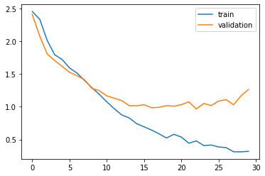

```python
# Fit the model with validation_split=0.5
history = classifier.fit(X_train,y_train,
                         batch_size=32,
                         epochs=30,
                         validation_data=(X_test, y_test),
                         validation_split=0.5,
                         shuffle=True,
                         verbose=1,
                         callbacks=[early_stopping,model_checkpoint])

# plot training history
plt.plot(history.history['loss'], label='train')
plt.plot(history.history['val_loss'], label='validation')
plt.legend()
plt.show()
```

```python
# Score trained model
scores = classifier.evaluate(X_test, y_test, verbose=1)
print('Test loss:', scores[0])
print('Test accuracy:', scores[1])
```

```
Test loss: 1.2817952632904053
Test accuracy: 0.6954386234283447
```

```python
#Calculate the confusion_matrix
y_pred = classifier.predict(X_test)
print("=== Confusion Matrix ===")
matrix = tensorflow.math.confusion_matrix(y_test.argmax(axis=1), y_pred.argmax(axis=1))
print(matrix)
```

```
=== Confusion Matrix ===
tf.Tensor(
[[  2   0   0   0   7   2  66   0   0   1   1   1]
 [  0  78  11   0   1   0   0   0   2  10   5   2]
 [  0   2  71   1   1  11   0   0   4   1   0   0]
 [  0   0   0 161   0   3   0   1   5  10   7   0]
 [  2   0   0   1  25   5  32   0   6   0   0   0]
 [  1   0   5   4   4 104  12   1   6   3   2   5]
 [  4   0   0   0   6   3 168   0   0   0   2   3]
 [  0   0   1  10   0   1   2  34   9   1   6   0]
 [  0   4   2   7   2   3   9   2 108  11   2  10]
 [  0   0   0   7   0   2   0   0  10  38   7   0]
 [  0   1   0   2   0   0   0   1   0   4 136   0]
 [  2   0   0   5   3  13   2   1  21   3   6  66]], shape=(12, 12), dtype=int32)
```

## Visualize Predictions

```
 This is the PREDICTED plant:

Predicted label: 10
Predicted plant: Small-flowered Cranesbill
Softmax Outputs: [[0. 0. 0. 0. 0. 0. 0. 0. 0. 0. 1. 0.]]
Sum of Softmax Outputs: 1.0

 This is the REAL plant:
```

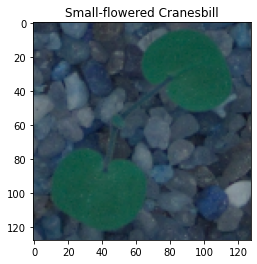

```python
# Verifying the predictions of the model with the real image for an ith image of the images dataset

# Predicted plant
i=100
y_predt = classifier.predict(images[i].reshape(1, 128, 128, 3))
n_plantt = y_predt.argmax()
print("\n This is the PREDICTED plant:\n")
print("Predicted label:", n_plantt)
print("Predicted plant:", labels1.index[n_plantt])
print("Softmax Outputs:", y_predt)
print("Sum of Softmax Outputs:",y_predt.sum())

#Real plant
print("\n This is the REAL plant:")
plt.title(str(labels.iloc[i,0]))
plt.imshow(images[i])
```

```
 This is the PREDICTED plant:

Predicted label: 9
Predicted plant: Shepherds Purse
Softmax Outputs: [[0. 0. 0. 0. 0. 0. 0. 0. 0. 1. 0. 0.]]
Sum of Softmax Outputs: 1.0

 This is the REAL plant:
```

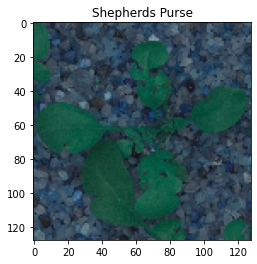

```python
# Verifying the predictions of the model with the real image for an ith image of the images dataset

# Predicted plant
i=1000
y_predt = classifier.predict(images[i].reshape(1, 128, 128, 3))
n_plantt = y_predt.argmax()
print("\n This is the PREDICTED plant:\n")
print("Predicted label:", n_plantt)
print("Predicted plant:", labels1.index[n_plantt])
print("Softmax Outputs:", y_predt)
print("Sum of Softmax Outputs:",y_predt.sum())

#Real plant
print("\n This is the REAL plant:")
plt.title(str(labels.iloc[i,0]))
plt.imshow(images[i])
```

```
 This is the PREDICTED plant:

Predicted label: 3
Predicted plant: Common Chickweed
Softmax Outputs: [[0. 0. 0. 1. 0. 0. 0. 0. 0. 0. 0. 0.]]
Sum of Softmax Outputs: 1.0

 This is the REAL plant:
```

[figure not shown]

```python
# Verifying the predictions of the model with the real image for an ith image of the images dataset

# Predicted plant
i=1500
y_predt = classifier.predict(images[i].reshape(1, 128, 128, 3))
n_plantt = y_predt.argmax()
print("\n This is the PREDICTED plant:\n")
print("Predicted label:", n_plantt)
print("Predicted plant:", labels1.index[n_plantt])
print("Softmax Outputs:", y_predt)
print("Sum of Softmax Outputs:",y_predt.sum())

#Real plant
print("\n This is the REAL plant:")
plt.title(str(labels.iloc[i,0]))
plt.imshow(images[i])
```